# MY459: Assignment 1Solutions

### Overview

The purpose of this assignment is to familiarize yourself with R, RMarkdown, and `quanteda`.

As with the rest of assignments throughout the term, the goal is to write R code in the chunks within this RMarkdown file that will accomplish the tasks detailed below. Where questions are asked, include your answer in the after the question.

Start by loading the `quanteda` package.

```r
library("quanteda")
```

You will use the corpus of inaugural addresses by U.S. presidents `data_corpus_inaugural` for this part of the exercise. These data are available as soon as you load `quanteda` and are lazily-loaded once you access them.

Write code to inspect which inaugural address was the longest. Have a look at `texts()` to extract character vectors from the quanteda corpus object.

```r
which.max(nchar(texts(data_corpus_inaugural)))
## 1841-Harrison
##            14
```

### Question 1 (3 points)

Explain how this answer works.

How could you do this using a **quanteda** function?

```r
# possible answers include

ntoken(data_corpus_inaugural) %>%
  sort(decreasing = TRUE) %>%
  head(n = 5)
## 1841-Harrison     1909-Taft     1845-Polk   1821-Monroe 1889-Harrison
##          9123          5821          5186          4886          4721

summary(data_corpus_inaugural)
## Corpus consisting of 58 documents, showing 58 documents:
##
##             Text Types Tokens Sentences Year  President       FirstName
##  1789-Washington   625   1537        23 1789 Washington          George
##  1793-Washington    96    147         4 1793 Washington          George
##       1797-Adams   826   2577        37 1797      Adams            John
##   1801-Jefferson   717   1923        41 1801  Jefferson          Thomas
##   1805-Jefferson   804   2380        45 1805  Jefferson          Thomas
##     1809-Madison   535   1261        21 1809    Madison           James
##     1813-Madison   541   1302        33 1813    Madison           James
##      1817-Monroe  1040   3677       121 1817     Monroe           James
##      1821-Monroe  1259   4886       131 1821     Monroe           James
##       1825-Adams  1003   3147        74 1825      Adams     John Quincy
##     1829-Jackson   517   1208        25 1829    Jackson          Andrew
##     1833-Jackson   499   1267        29 1833    Jackson          Andrew
##    1837-VanBuren  1315   4158        95 1837  Van Buren          Martin
##    1841-Harrison  1898   9123       210 1841   Harrison   William Henry
##        1845-Polk  1334   5186       153 1845       Polk      James Knox
##      1849-Taylor   496   1178        22 1849     Taylor         Zachary
##      1853-Pierce  1165   3636       104 1853     Pierce        Franklin
##    1857-Buchanan   945   3083        89 1857   Buchanan           James
##     1861-Lincoln  1075   3999       135 1861    Lincoln         Abraham
##     1865-Lincoln   360    775        26 1865    Lincoln         Abraham
##       1869-Grant   485   1229        40 1869      Grant      Ulysses S.
##       1873-Grant   552   1472        43 1873      Grant      Ulysses S.
##       1877-Hayes   831   2707        59 1877      Hayes   Rutherford B.
##    1881-Garfield  1021   3209       111 1881   Garfield        James A.
##   1885-Cleveland   676   1816        44 1885  Cleveland          Grover
##    1889-Harrison  1352   4721       157 1889   Harrison        Benjamin
##   1893-Cleveland   821   2125        58 1893  Cleveland          Grover
##    1897-McKinley  1232   4353       130 1897   McKinley         William
##    1901-McKinley   854   2437       100 1901   McKinley         William
##   1905-Roosevelt   404   1079        33 1905  Roosevelt        Theodore
##        1909-Taft  1437   5821       158 1909       Taft  William Howard
##      1913-Wilson   658   1882        68 1913     Wilson         Woodrow
##      1917-Wilson   549   1652        59 1917     Wilson         Woodrow
##     1921-Harding  1169   3719       148 1921    Harding       Warren G.
##    1925-Coolidge  1220   4440       196 1925   Coolidge          Calvin
##      1929-Hoover  1090   3860       158 1929     Hoover         Herbert
##   1933-Roosevelt   743   2057        85 1933  Roosevelt     Franklin D.
##   1937-Roosevelt   725   1989        96 1937  Roosevelt     Franklin D.
##   1941-Roosevelt   526   1519        68 1941  Roosevelt     Franklin D.
##   1945-Roosevelt   275    633        27 1945  Roosevelt     Franklin D.
##      1949-Truman   781   2504       116 1949     Truman        Harry S.
##  1953-Eisenhower   900   2743       119 1953 Eisenhower       Dwight D.
##  1957-Eisenhower   621   1907        92 1957 Eisenhower       Dwight D.
##     1961-Kennedy   566   1541        52 1961    Kennedy         John F.
##     1965-Johnson   568   1710        93 1965    Johnson   Lyndon Baines
##       1969-Nixon   743   2416       103 1969      Nixon Richard Milhous
##       1973-Nixon   544   1995        68 1973      Nixon Richard Milhous
##      1977-Carter   527   1369        52 1977     Carter           Jimmy
##      1981-Reagan   902   2780       129 1981     Reagan          Ronald
##      1985-Reagan   925   2909       123 1985     Reagan          Ronald
##        1989-Bush   795   2673       141 1989       Bush          George
##     1993-Clinton   642   1833        81 1993    Clinton            Bill
##     1997-Clinton   773   2436       111 1997    Clinton            Bill
##        2001-Bush   621   1806        97 2001       Bush       George W.
##        2005-Bush   772   2312        99 2005       Bush       George W.
##       2009-Obama   938   2689       110 2009      Obama          Barack
##       2013-Obama   814   2317        88 2013      Obama          Barack
##       2017-Trump   582   1660        88 2017      Trump       Donald J.
##                  Party
##                   none
##                   none
##             Federalist
##  Democratic-Republican
##  Democratic-Republican
##  Democratic-Republican
##  Democratic-Republican
##  Democratic-Republican
##  Democratic-Republican
##  Democratic-Republican
##             Democratic
##             Democratic
##             Democratic
##                   Whig
##                   Whig
##                   Whig
##             Democratic
##             Democratic
##             Republican
##             Republican
##             Republican
##             Republican
##             Republican
##             Republican
##             Democratic
##             Republican
##             Democratic
##             Republican
##             Republican
##             Republican
##             Republican
##             Democratic
##             Democratic
##             Republican
##             Republican
##             Republican
##             Democratic
##             Democratic
##             Democratic
##             Democratic
##             Democratic
##             Republican
##             Republican
##             Democratic
##             Democratic
##             Republican
##             Republican
##             Democratic
##             Republican
##             Republican
##             Republican
##             Democratic
##             Democratic
##             Republican
##             Republican
##             Democratic
##             Democratic
##             Republican
```

### Question 2 (3 points)

Which president gave the longest speech and in what year was that?

```r
which.max(nchar(texts(data_corpus_inaugural)))
## 1841-Harrison
##            14
```

### Question 3 (4 points)

Generate a document-feature matrix from this corpus and call it `sotu_dfm`. Make sure that the text is put into **lowercase** and words are **stemmed** as preprocessing steps.

```r
sotu_dfm <- dfm(data_corpus_inaugural, tolower = TRUE, stem = TRUE)
```

Now, look at the 20 most common features in the document-feature matrix. Hint: `?topfeatures`

```r
# examine top 20 common features
topfeatures(sotu_dfm, n = 20)
```

```
##   the    of     ,   and     .    to    in     a   our    it  that    we    be
## 10082  7103  7026  5310  4945  4526  2785  2246  2203  1962  1792  1739  1544
##    is   for    by  have which  with   not
##  1462  1197  1083  1057  1006   958   957
```

What do most of those tokens have in common?

What step(s) might you take to focus on a more interesting set of word frequencies? Write code below to apply those steps, if you consider it necessary.

##### Model answer

*All of them are function words or punctuation. Words like that can be considered stopwords and are often excluded from bag-of-words analyses.*

Now generate a second document-feature matrix but remove punctuation and remove stopwords. Call this object `sotu_dfm_sp`.

```r
sotu_dfm_sp <- dfm(data_corpus_inaugural, tolower = TRUE, stem = TRUE, remove = stopwords("english"), remove_punct = TRUE)
```

Now look at the 20 most common features again. The most common words are now no longer uninteresting words.

```r
topfeatures(sotu_dfm_sp, n = 20)
```

```
##    nation    govern     peopl        us       can     state     great      upon
##       675       657       623       478       471       450       373       371
##     power      must   countri     world       may     shall     everi constitut
##       370       366       355       339       338       314       298       286
##      peac     right       law      time
##       283       276       271       267
```

To go further, we could also have used the `remove_numbers = TRUE` argument. Note that in **quanteda**, it is possible to tokenize the corpus first, using `tokens()`, and then create the dfm from those tokens. This provides an additional amount of control, through the many functions available in the [`tokens_*()` functions](http://docs.quanteda.io/reference/#section-tokens-functions).

### Question 4 (3 points)

Write code to figure out how many different types of punctuation and how many different types of stopwords were removed.

```r
# Simple
dfm(data_corpus_inaugural, tolower = TRUE, stem = TRUE, remove = stopwords("english"), remove_punct = TRUE, verbose = TRUE)
## Creating a dfm from a corpus input...
##  ...lowercasing
##  ...found 58 documents, 9,346 features
##  ...removed 136 features
##  ...stemming types (English)
##  ...complete, elapsed time: 0.299 seconds.
## Finished constructing a 58 x 5,410 sparse dfm.
## Document-feature matrix of: 58 documents, 5,410 features (89.2% sparse) and 4 docvars.
##                  features
## docs              fellow-citizen senat hous repres among vicissitud incid life
##   1789-Washington              1     1    2      2     1          1     1    1
##   1793-Washington              0     0    0      0     0          0     0    0
##   1797-Adams                   3     1    3      3     4          0     0    2
##   1801-Jefferson               2     0    0      1     1          0     0    1
##   1805-Jefferson               0     0    0      0     7          0     0    2
##   1809-Madison                 1     0    0      1     0          1     0    1
##                  features
## docs              event fill
##   1789-Washington     2    1
##   1793-Washington     0    0
##   1797-Adams          0    0
##   1801-Jefferson      0    0
##   1805-Jefferson      1    0
##   1809-Madison        0    1
## [ reached max_ndoc ... 52 more documents, reached max_nfeat ... 5,400 more features ]

# More complicated, hand-crafted solution
nfeat(dfm(data_corpus_inaugural, tolower = TRUE, stem = TRUE)) -
  nfeat(dfm(data_corpus_inaugural, tolower = TRUE, stem = TRUE, remove = stopwords("english"), remove_punct = TRUE))
```

```
## [1] 134
```

### Question 5 (3 points)

Plot a wordcloud of the dfm that has the stopwords and punctuation characters, and numbers removed, but without stemming. Plot this only for words with a minimum count of 10. Hint: Use `textplot_wordcloud()` to generate the plot.

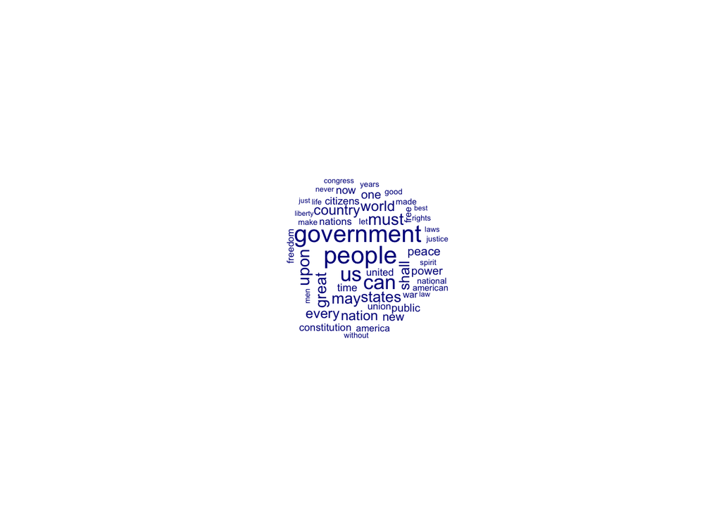

```r
# Generate dfm
sotu_dfm_spn <- dfm(data_corpus_inaugural, tolower = TRUE, stem = FALSE, remove = stopwords("english"), remove_punct = TRUE, remove_numbers = TRUE)
# Remove words (types) with less than 10 occurrences
sotu_dfm_spn <- dfm_trim(sotu_dfm_spn, min_termfreq = 10, verbose = TRUE)
## Removing features occurring:
##   - fewer than 10 times: 7,752
##   Total features removed: 7,752 (84.8%).
set.seed(123)
textplot_wordcloud(sotu_dfm_spn, min_size=.2, max_size=2, max_words=50)
```

### Question 6 (2 points)

Search for the word “Christmas” from the `data_corpus_irishbudget2010` object. What is the context in which this term is being used?

```r
# install.packages("quanteda.textmodels")
data("data_corpus_irishbudget2010", package = "quanteda.textmodels")
kwic(data_corpus_irishbudget2010, "Christmas*")
```

```
##
##       [Bruton, Richard (FG), 699]               and to see out this | Christmas
##         [Burton, Joan (LAB), 419]           to suggest titles for a | Christmas
##         [Burton, Joan (LAB), 428]      Fianna Fáil's hit single for | Christmas
##        [Burton, Joan (LAB), 1039]      women will say goodbye after | Christmas
##        [Burton, Joan (LAB), 1701]         in single golf clubs this | Christmas
##        [Burton, Joan (LAB), 1929] Community faking its message this | Christmas
##        [Burton, Joan (LAB), 3508]            . In previous years at | Christmas
##        [Morgan, Arthur (SF), 374]               204 per week or the | Christmas
##       [Morgan, Arthur (SF), 3550]   to social welfare payments this | Christmas
##       [Morgan, Arthur (SF), 3556]                 . The loss of the | Christmas
##       [Morgan, Arthur (SF), 3586]     streets on Santa presents and | Christmas
##       [Morgan, Arthur (SF), 6490]               jobs, who face this | Christmas
##          [Kenny, Enda (FG), 2873] to implement the reduction before | Christmas
##     [ODonnell, Kieran (FG), 1510]            from the change in the | Christmas
##       [Gilmore, Eamon (LAB), 608]              € 641, including the | Christmas
##       [Gilmore, Eamon (LAB), 712]            on social welfare, the | Christmas
##      [Gilmore, Eamon (LAB), 1112]       emigration. Once again this | Christmas
##      [Cuffe, Ciaran (Green), 992]      noted recently that over the | Christmas
##  [OCaolain, Caoimhghin (SF), 167]               will all be over by | Christmas
##
##  | in the hope of something
##  | hit single. Fianna Fáil's
##  | will be," I
##  | because they must take the
##  | . With a possible election
##  | ? Is the Society of
##  | time people were laden down
##  | bonus. Of course,
##  | . The loss of the
##  | bonus, a double payment
##  | food. The Government's Scrooge
##  | in debt, in poverty
##  | . I do not know
##  | period. We suggested that
##  | payment. A couple on
##  | payment is gone. Earnest
##  | , we will witness the
##  | recess work will be done
##  | . If it is the
```

Search for the word “Irish” and save the results of this keywords-in-context object to a new object called `irish_kwic`. Plot an “x-ray” plot for this kwic, in the code bloc below:

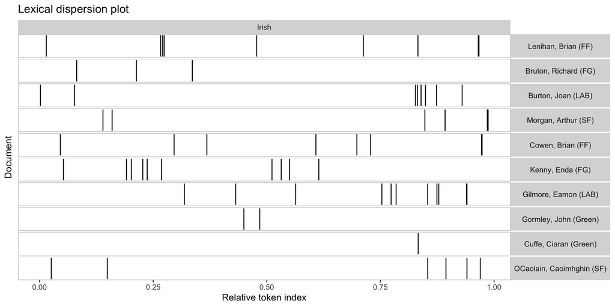

```r
irish_kwic <- kwic(data_corpus_irishbudget2010, pattern = "Irish")
textplot_xray(irish_kwic)
```

#### Question 7 (2 points)

Examine the context of words *related to* “disaster”. Hint: you can use the stem of the word along with setting the `regex` argument to `TRUE`. Execute a query using a pattern match that returns different variations of words based on “disaster” (such as disasters, disastrous, disastrously, etc.).

```r
# Other regular expression are possible here
kwic(data_corpus_irishbudget2010, pattern = "disast[A-Za-z]*", valuetype = "regex")
```

```
##
##       [Bruton, Richard (FG), 3020]     . Instead the Government has |
##          [Burton, Joan (LAB), 565]             VAT, the single most |
##        [Morgan, Arthur (SF), 1143]        which was caused by their |
##            [Kenny, Enda (FG), 211]    in our recovery from economic |
##       [Gilmore, Eamon (LAB), 1421]        to deal with the economic |
##       [Gilmore, Eamon (LAB), 1571]  commitment to dealing with this |
##       [Gilmore, Eamon (LAB), 3661] and international. Following the |
##   [OCaolain, Caoimhghin (SF), 835]           however, thanks to the |
##  [OCaolain, Caoimhghin (SF), 3682]        is an alternative to this |
##  [OCaolain, Caoimhghin (SF), 3847]    are fighting back against the |
##
##  disastrously | mishandled those negotiations and it
##   disastrous  | action he took in the
##   disastrous  | policies and gross mismanagement.
##    disaster   | . That was the view
##    disaster   | that it created. The
##    disaster   | even if it was of
##   disastrous  | handling of the banking crisis
##   disastrous  | policies and gross mismanagement of
##   disastrous  | budget. Sinn Féin presented
##   disastrous  | policies of this Fianna Fáil
```